# AI CA#0 Mahdi HajiSeyedHossein

## Purpose of the CA : cleaning a dataset & predict by a simple statistical model

##### In this CA I cleaned a dataset that was about the people and their SALARY based on their humanical informations , and I found best proprty of a human to predic his of her SALARY based on that proprty

```python
import pandas as pd
import numpy as np
```

##### This DataSet was given by TA and it was about some informations on people and then catogorized them based on their SALARY (THIS WAS TRAIN DF)

```python
trainDF = pd.read_csv("/Users/Mahdi/Downloads/train.csv")
```

# Question 2 : Usual Methods On DataFrame

### -describe

```python
trainDF.describe()
```

|  | age | fnlwgt | education-num | capital-gain | capital-loss | hours-per-week |
| --- | --- | --- | --- | --- | --- | --- |
| count | 29825.000000 | 2.982500e+04 | 29825.000000 | 29825.000000 | 29825.000000 | 29825.000000 |
| mean | 38.581425 | 1.897389e+05 | 10.079229 | 1094.586052 | 86.476513 | 40.434334 |
| std | 13.652005 | 1.053738e+05 | 2.571678 | 7485.908646 | 401.195078 | 12.308174 |
| min | 17.000000 | 1.228500e+04 | 1.000000 | 0.000000 | 0.000000 | 1.000000 |
| 25% | 28.000000 | 1.178490e+05 | 9.000000 | 0.000000 | 0.000000 | 40.000000 |
| 50% | 37.000000 | 1.785170e+05 | 10.000000 | 0.000000 | 0.000000 | 40.000000 |
| 75% | 48.000000 | 2.368790e+05 | 12.000000 | 0.000000 | 0.000000 | 45.000000 |
| max | 90.000000 | 1.484705e+06 | 16.000000 | 99999.000000 | 4356.000000 | 99.000000 |

this method generate some descriptive statistics about DF.

### -tail

```python
trainDF.tail(3)
```

|  | age | workclass | fnlwgt | education | education-num | marital-status | occupation | relationship | race | sex | capital-gain | capital-loss | hours-per-week | native-country | salary |
| --- | --- | --- | --- | --- | --- | --- | --- | --- | --- | --- | --- | --- | --- | --- | --- |
| 29822 | 47 | Local-gov | 191389 | HS-grad | 9 | Divorced | Adm-clerical | Unmarried | White | Female | 0 | 0 | 35 | United-States | <=50K |
| 29823 | 38 | Private | 187983 | Prof-school | 15 | Married-civ-spouse | Sales | Wife | White | Female | 0 | 0 | 40 | United-States | <=50K |
| 29824 | 18 | Private | 215110 | HS-grad | 9 | Never-married | Handlers-cleaners | Own-child | Black | Male | 0 | 0 | 40 | United-States | <=50K |

this method show last n records on DF by method input n (default value for n is 5)

### -head

```python
trainDF.head(4)
```

|  | age | workclass | fnlwgt | education | education-num | marital-status | occupation | relationship | race | sex | capital-gain | capital-loss | hours-per-week | native-country | salary |
| --- | --- | --- | --- | --- | --- | --- | --- | --- | --- | --- | --- | --- | --- | --- | --- |
| 0 | 39 | State-gov | 77516 | Bachelors | 13 | Never-married | Adm-clerical | Not-in-family | White | Male | 2174 | 0 | 40 | United-States | <=50K |
| 1 | 50 | Self-emp-not-inc | 83311 | Bachelors | 13 | Married-civ-spouse | Exec-managerial | Husband | White | Male | 0 | 0 | 13 | United-States | <=50K |
| 2 | 38 | Private | 215646 | HS-grad | 9 | Divorced | Handlers-cleaners | Not-in-family | White | Male | 0 | 0 | 40 | United-States | <=50K |
| 3 | 53 | Private | 234721 | 11th | 7 | Married-civ-spouse | Handlers-cleaners | Husband | Black | Male | 0 | 0 | 40 | United-States | <=50K |

this method show first n records on DF by method input n (default value for n is 5)

### -info

```python
trainDF.info()
```

```
<class 'pandas.core.frame.DataFrame'>
RangeIndex: 29825 entries, 0 to 29824
Data columns (total 15 columns):
 #   Column          Non-Null Count  Dtype
---  ------          --------------  -----
 0   age             29825 non-null  int64
 1   workclass       28154 non-null  object
 2   fnlwgt          29825 non-null  int64
 3   education       29825 non-null  object
 4   education-num   29825 non-null  int64
 5   marital-status  29825 non-null  object
 6   occupation      28149 non-null  object
 7   relationship    29825 non-null  object
 8   race            29825 non-null  object
 9   sex             29825 non-null  object
 10  capital-gain    29825 non-null  int64
 11  capital-loss    29825 non-null  int64
 12  hours-per-week  29825 non-null  int64
 13  native-country  29288 non-null  object
 14  salary          29825 non-null  object
dtypes: int64(6), object(9)
memory usage: 3.4+ MB
```

Print a concise summary of a DataFrame.

# *__*

```python
trainDF.info()
print("************************")
trainDF['workclass'].info()
print("************************")
```

```
<class 'pandas.core.frame.DataFrame'>
RangeIndex: 29825 entries, 0 to 29824
Data columns (total 15 columns):
 #   Column          Non-Null Count  Dtype
---  ------          --------------  -----
 0   age             29825 non-null  int64
 1   workclass       28154 non-null  object
 2   fnlwgt          29825 non-null  int64
 3   education       29825 non-null  object
 4   education-num   29825 non-null  int64
 5   marital-status  29825 non-null  object
 6   occupation      28149 non-null  object
 7   relationship    29825 non-null  object
 8   race            29825 non-null  object
 9   sex             29825 non-null  object
 10  capital-gain    29825 non-null  int64
 11  capital-loss    29825 non-null  int64
 12  hours-per-week  29825 non-null  int64
 13  native-country  29288 non-null  object
 14  salary          29825 non-null  object
dtypes: int64(6), object(9)
memory usage: 3.4+ MB
<class 'pandas.core.series.Series'>
RangeIndex: 29825 entries, 0 to 29824
Series name: workclass
Non-Null Count  Dtype
--------------  -----
28154 non-null  object
dtypes: object(1)
memory usage: 233.1+ KB
```

```python
trainDF.dtypes
```

```
age                int64
workclass         object
fnlwgt             int64
education         object
education-num      int64
marital-status    object
occupation        object
relationship      object
race              object
sex               object
capital-gain       int64
capital-loss       int64
hours-per-week     int64
native-country    object
salary            object
dtype: object
```

# Question 2 : Categorical & Numerical (LABEL ENCODE)

```python
trainDF['salary'].unique()
```

```
array(['<=50K', '>50K'], dtype=object)
```

```python
enDF = trainDF.copy()
```

### this was an unsuccessful try

```python
#enDF = enDF.apply(lambda x : pd.factorize(x)[0])
```

```python
def DF_LE(enDF):
    for col in enDF :
        if (enDF[col].dtypes == object):
            enDF[col] = enDF[col].astype('category').cat.codes
DF_LE(enDF)
```

```python
enDF.head()
```

|  | age | workclass | fnlwgt | education | education-num | marital-status | occupation | relationship | race | sex | capital-gain | capital-loss | hours-per-week | native-country | salary |
| --- | --- | --- | --- | --- | --- | --- | --- | --- | --- | --- | --- | --- | --- | --- | --- |
| 0 | 39 | 6 | 77516 | 9 | 13 | 4 | 0 | 1 | 4 | 1 | 2174 | 0 | 40 | 38 | 0 |
| 1 | 50 | 5 | 83311 | 9 | 13 | 2 | 3 | 0 | 4 | 1 | 0 | 0 | 13 | 38 | 0 |
| 2 | 38 | 3 | 215646 | 11 | 9 | 0 | 5 | 1 | 4 | 1 | 0 | 0 | 40 | 38 | 0 |
| 3 | 53 | 3 | 234721 | 1 | 7 | 2 | 5 | 0 | 2 | 1 | 0 | 0 | 40 | 38 | 0 |
| 4 | 28 | 3 | 338409 | 9 | 13 | 2 | 9 | 5 | 2 | 0 | 0 | 0 | 40 | 4 | 0 |

```python
trainDF.head()
```

|  | age | workclass | fnlwgt | education | education-num | marital-status | occupation | relationship | race | sex | capital-gain | capital-loss | hours-per-week | native-country | salary |
| --- | --- | --- | --- | --- | --- | --- | --- | --- | --- | --- | --- | --- | --- | --- | --- |
| 0 | 39 | State-gov | 77516 | Bachelors | 13 | Never-married | Adm-clerical | Not-in-family | White | Male | 2174 | 0 | 40 | United-States | <=50K |
| 1 | 50 | Self-emp-not-inc | 83311 | Bachelors | 13 | Married-civ-spouse | Exec-managerial | Husband | White | Male | 0 | 0 | 13 | United-States | <=50K |
| 2 | 38 | Private | 215646 | HS-grad | 9 | Divorced | Handlers-cleaners | Not-in-family | White | Male | 0 | 0 | 40 | United-States | <=50K |
| 3 | 53 | Private | 234721 | 11th | 7 | Married-civ-spouse | Handlers-cleaners | Husband | Black | Male | 0 | 0 | 40 | United-States | <=50K |
| 4 | 28 | Private | 338409 | Bachelors | 13 | Married-civ-spouse | Prof-specialty | Wife | Black | Female | 0 | 0 | 40 | Cuba | <=50K |

```python
trainDF.head()
```

|  | age | workclass | fnlwgt | education | education-num | marital-status | occupation | relationship | race | sex | capital-gain | capital-loss | hours-per-week | native-country | salary |
| --- | --- | --- | --- | --- | --- | --- | --- | --- | --- | --- | --- | --- | --- | --- | --- |
| 0 | 39 | State-gov | 77516 | Bachelors | 13 | Never-married | Adm-clerical | Not-in-family | White | Male | 2174 | 0 | 40 | United-States | <=50K |
| 1 | 50 | Self-emp-not-inc | 83311 | Bachelors | 13 | Married-civ-spouse | Exec-managerial | Husband | White | Male | 0 | 0 | 13 | United-States | <=50K |
| 2 | 38 | Private | 215646 | HS-grad | 9 | Divorced | Handlers-cleaners | Not-in-family | White | Male | 0 | 0 | 40 | United-States | <=50K |
| 3 | 53 | Private | 234721 | 11th | 7 | Married-civ-spouse | Handlers-cleaners | Husband | Black | Male | 0 | 0 | 40 | United-States | <=50K |
| 4 | 28 | Private | 338409 | Bachelors | 13 | Married-civ-spouse | Prof-specialty | Wife | Black | Female | 0 | 0 | 40 | Cuba | <=50K |

# Question 3 : NaN values

```python
NaNValue_1 = trainDF[trainDF.isna().any(axis=1)]
```

```python
NaNValue_2 = enDF[enDF.isna().any(axis=1)]
```

```python
NaNValue_1
```

|  | age | workclass | fnlwgt | education | education-num | marital-status | occupation | relationship | race | sex | capital-gain | capital-loss | hours-per-week | native-country | salary |
| --- | --- | --- | --- | --- | --- | --- | --- | --- | --- | --- | --- | --- | --- | --- | --- |
| 14 | 40 | Private | 121772 | Assoc-voc | 11 | Married-civ-spouse | Craft-repair | Husband | Asian-Pac-Islander | Male | 0 | 0 | 40 | NaN | >50K |
| 27 | 54 | NaN | 180211 | Some-college | 10 | Married-civ-spouse | NaN | Husband | Asian-Pac-Islander | Male | 0 | 0 | 60 | South | >50K |
| 38 | 31 | Private | 84154 | Some-college | 10 | Married-civ-spouse | Sales | Husband | White | Male | 0 | 0 | 38 | NaN | >50K |
| 51 | 18 | Private | 226956 | HS-grad | 9 | Never-married | Other-service | Own-child | White | Female | 0 | 0 | 30 | NaN | <=50K |
| 61 | 32 | NaN | 293936 | 7th-8th | 4 | Married-spouse-absent | NaN | Not-in-family | White | Male | 0 | 0 | 40 | NaN | <=50K |
| ... | ... | ... | ... | ... | ... | ... | ... | ... | ... | ... | ... | ... | ... | ... | ... |
| 29791 | 64 | NaN | 146272 | Some-college | 10 | Married-civ-spouse | NaN | Husband | White | Male | 3411 | 0 | 15 | United-States | <=50K |
| 29798 | 32 | NaN | 119522 | Bachelors | 13 | Divorced | NaN | Not-in-family | White | Male | 0 | 0 | 50 | United-States | <=50K |
| 29807 | 19 | NaN | 28455 | Some-college | 10 | Never-married | NaN | Own-child | White | Female | 0 | 0 | 40 | United-States | <=50K |
| 29814 | 55 | NaN | 193895 | 7th-8th | 4 | Divorced | NaN | Unmarried | White | Female | 0 | 0 | 40 | United-States | <=50K |
| 29819 | 52 | NaN | 244214 | HS-grad | 9 | Married-civ-spouse | NaN | Husband | White | Male | 0 | 0 | 35 | United-States | <=50K |

2188 rows × 15 columns

```python
NaNValue_2
```

|  | age | workclass | fnlwgt | education | education-num | marital-status | occupation | relationship | race | sex | capital-gain | capital-loss | hours-per-week | native-country | salary |
| --- | --- | --- | --- | --- | --- | --- | --- | --- | --- | --- | --- | --- | --- | --- | --- |

### there is a problem: - this is wrong that first we label encode columns and then fill NaN value , becuase pandas label NaN value with a code and then there is no NaNValue

### so we can first fill NaN and then label them

```python
enDF = trainDF.copy()
```

```python
enDF.isnull().sum()
```

```
age                  0
workclass         1671
fnlwgt               0
education            0
education-num        0
marital-status       0
occupation        1676
relationship         0
race                 0
sex                  0
capital-gain         0
capital-loss         0
hours-per-week       0
native-country     537
salary               0
dtype: int64
```

##### DataFrame.fillna(value=None, *, method=None, axis=None, inplace=False, limit=None, downcast=None)

```
To fill NaN values , some variables have discrete value and some of them have continuis value , for example sex has only two value like MALE and FEMALE (that with label encoding they transform to 1 or 0) so to fill NaN value of sex you cannot put mean in them like 1.4 :))))
 Deleting the data is definitely a very bad option


- advantages :
    It reduces the variance
    No significant loss of data (~0.1%)
    Easy to implement
    Preserves the distribution
    Filling NaN values with the mean does not introduce any bias in the data


- disadvantages :
    Can reduce variance
    Can distort correlation
    ** Not suitable for categorical data
    For a particular cateory, all null values present for a column




In summary, filling NaN values with the mean is a simple and quick method of imputing missing data that has some advantages, but also some disadvantages. The suitability of this method depends on the nature of the data and the requirements of the subsequent analysis.
```

```python
fillNaNValues = {'workclass' : trainDF['workclass'].mode()[0] , 'occupation' : trainDF['occupation'].mode()[0],
                'native-country' : trainDF['native-country'].mode()[0]}
```

##### introduce mode function

```python
trainDF['occupation'].value_counts()
```

```
Prof-specialty       3773
Craft-repair         3759
Exec-managerial      3706
Adm-clerical         3491
Sales                3356
Other-service        3029
Machine-op-inspct    1839
Transport-moving     1464
Handlers-cleaners    1244
Farming-fishing       906
Tech-support          849
Protective-serv       582
Priv-house-serv       143
Armed-Forces            8
Name: occupation, dtype: int64
```

```python
trainDF['occupation'].mode()[0]
```

```
'Prof-specialty'
```

```python
enDF.fillna(value=fillNaNValues , inplace=True)
```

```python
enDF.isnull().sum()
```

```
age               0
workclass         0
fnlwgt            0
education         0
education-num     0
marital-status    0
occupation        0
relationship      0
race              0
sex               0
capital-gain      0
capital-loss      0
hours-per-week    0
native-country    0
salary            0
dtype: int64
```

##### Label encode it after filling NaN Values

```python
DF_LE(enDF)
```

```python
enDF.head(3)
```

|  | age | workclass | fnlwgt | education | education-num | marital-status | occupation | relationship | race | sex | capital-gain | capital-loss | hours-per-week | native-country | salary |
| --- | --- | --- | --- | --- | --- | --- | --- | --- | --- | --- | --- | --- | --- | --- | --- |
| 0 | 39 | 6 | 77516 | 9 | 13 | 4 | 0 | 1 | 4 | 1 | 2174 | 0 | 40 | 38 | 0 |
| 1 | 50 | 5 | 83311 | 9 | 13 | 2 | 3 | 0 | 4 | 1 | 0 | 0 | 13 | 38 | 0 |
| 2 | 38 | 3 | 215646 | 11 | 9 | 0 | 5 | 1 | 4 | 1 | 0 | 0 | 40 | 38 | 0 |

# Question 4 : Spesifice Value

##### In this DF ; there was no column to delete becuase of its specific value for checking that we can use unique() function of DF and check it with number of RECORDS

```python
len(enDF['fnlwgt'].unique())

#this was the most specific value for columns
```

```
20337
```

# Question 5 : Conditions On Columns

```python
trainDF['sex'].value_counts()
```

```
Male      19956
Female     9869
Name: sex, dtype: int64
```

```python
enDF['sex'].value_counts()
```

```
1    19956
0     9869
Name: sex, dtype: int64
```

```python
print (trainDF['relationship'].unique() , "\n\n")
print (trainDF['marital-status'].unique())
```

```
['Not-in-family' 'Husband' 'Wife' 'Own-child' 'Unmarried' 'Other-relative']


['Never-married' 'Married-civ-spouse' 'Divorced' 'Married-spouse-absent'
 'Separated' 'Married-AF-spouse' 'Widowed']
```

##### - becuase unique value of marrige-status column was more than relationship column and it was easier but i didn't chose that - marital status of an individual. Married-civ-spouse corresponds to a civilian spouse while Married-AF-spouse is a spouse in the Armed Forces.

```python
NumberOfMarriedMales = trainDF[(trainDF['sex'] == 'Male') & (trainDF['marital-status'] == 'Married-civ-spouse')
       | (trainDF['sex'] == 'Male') & (trainDF['marital-status'] == 'Married-AF-spouse')].shape[0]
```

```python
print("the Number Of married Males is : {}" .format(NumberOfMarriedMales))
```

```
the Number Of married Males is : 12177
```

# Question 6 : Conditions On Columns

```python
trainDF['workclass'].unique()
```

```
array(['State-gov', 'Self-emp-not-inc', 'Private', 'Federal-gov',
       'Local-gov', nan, 'Self-emp-inc', 'Without-pay', 'Never-worked'],
      dtype=object)
```

```python
NumberOfBlackPrivateOlder30 = trainDF[(trainDF['race'] == 'Black') &
                                     (trainDF['age'] > 30) &
                                     (trainDF['workclass'] == 'Private')].shape[0]
```

```python
print ("Number of people who are BLACK and OLDER THAN 30 and their workclass is PRIVATE : {}"
       .format(NumberOfBlackPrivateOlder30))
```

```
Number of people who are BLACK and OLDER THAN 30 and their workclass is PRIVATE : 1274
```

# Question 7 : Mean

##### First step : we can seperate datas with conditions on columns

```python
trainDF[(trainDF['education'] == 'Bachelors')].head(5)
```

|  | age | workclass | fnlwgt | education | education-num | marital-status | occupation | relationship | race | sex | capital-gain | capital-loss | hours-per-week | native-country | salary |
| --- | --- | --- | --- | --- | --- | --- | --- | --- | --- | --- | --- | --- | --- | --- | --- |
| 0 | 39 | State-gov | 77516 | Bachelors | 13 | Never-married | Adm-clerical | Not-in-family | White | Male | 2174 | 0 | 40 | United-States | <=50K |
| 1 | 50 | Self-emp-not-inc | 83311 | Bachelors | 13 | Married-civ-spouse | Exec-managerial | Husband | White | Male | 0 | 0 | 13 | United-States | <=50K |
| 4 | 28 | Private | 338409 | Bachelors | 13 | Married-civ-spouse | Prof-specialty | Wife | Black | Female | 0 | 0 | 40 | Cuba | <=50K |
| 9 | 42 | Private | 159449 | Bachelors | 13 | Married-civ-spouse | Exec-managerial | Husband | White | Male | 5178 | 0 | 40 | United-States | >50K |
| 11 | 30 | State-gov | 141297 | Bachelors | 13 | Married-civ-spouse | Prof-specialty | Husband | Asian-Pac-Islander | Male | 0 | 0 | 40 | India | >50K |

##### Second step : Then we can watch an specifice column

```python
trainDF[(trainDF['education'] == 'Bachelors')]['hours-per-week'].head(5)
```

```
0     40
1     13
4     40
9     40
11    40
Name: hours-per-week, dtype: int64
```

##### Third step : we can specife the mean of that column

```python
meanOfHoursBachelors = trainDF[(trainDF['education'] == 'Bachelors')]['hours-per-week'].mean()
```

```python
print ("Mean of hours per work for Bachelos people is : {:.5f}"
      .format(meanOfHoursBachelors))
```

```
Mean of hours per work for Bachelos people is : 42.54667
```

# Question 8 : Loop vs Vectorize

```python
def meanWithLoop(df):
    count = 0
    sumOfHours = 0
    for inx in df.index:
        if (df['education'][inx] == 'Bachelors'):
            sumOfHours += df['hours-per-week'][inx]
            count += 1
    return (sumOfHours / count)
```

```python
print ("The value with loop iterator is same : {:.5f}"
      .format(meanWithLoop(trainDF)))
```

```
The value with loop iterator is same : 42.54667
```

### Now I comapere the Compute Times

```python
import time
```

```python
#Vectorized :

p_tic = time.perf_counter()
tic = time.time()

##
res1 = trainDF[(trainDF['education'] == 'Bachelors')]['hours-per-week'].mean()
##

toc = time.time()
p_toc = time.perf_counter()

print (f"(vectorized) result is : {res1}")
print (f"(vectorized) Compute time: {round(1000 * (toc - tic), 6)}ms")
print(f'(vectorized) Compute time (cpu) : {round(1000 * (p_toc - p_tic), 6)}ms')
```

```
(vectorized) result is : 42.546669366268475
(vectorized) Compute time: 4.542828ms
(vectorized) Compute time (cpu) : 4.632997ms
```

```python
#Loop iterateor :
p_tic = time.perf_counter()
tic = time.time()

##
res2 = meanWithLoop(trainDF)
##

toc = time.time()
p_toc = time.perf_counter()

print (f"(vectorized) result is : {res2}")
print (f"(vectorized) Compute time: {round(1000 * (toc - tic), 6)}ms")
print(f'(vectorized) Compute time (cpu) : {round(1000 * (p_toc - p_tic), 6)}ms')
```

```
(vectorized) result is : 42.546669366268475
(vectorized) Compute time: 334.770918ms
(vectorized) Compute time (cpu) : 334.869679ms
```

##### As you can see , vectorized is much better than loop

# Question 9 : Distribution

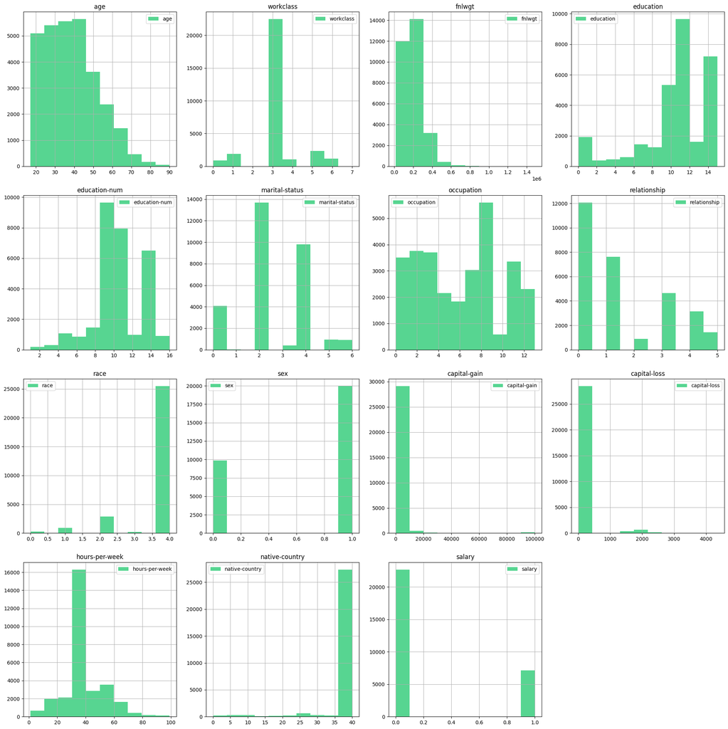

```python
import matplotlib.pyplot as plt
enDF.hist(alpha = 0.9,layout=(4 ,4), figsize=(20 , 20) , xlabelsize=10 , ylabelsize=10 ,legend=True , grid = True
         ,color='#45D185' )
plt.tight_layout()
plt.show()
```

##### if I hadn't use matplotlib then the figure would be like this :

```
array([[<AxesSubplot: title={'center': 'age'}>,
        <AxesSubplot: title={'center': 'workclass'}>,
        <AxesSubplot: title={'center': 'fnlwgt'}>,
        <AxesSubplot: title={'center': 'education'}>],
       [<AxesSubplot: title={'center': 'education-num'}>,
        <AxesSubplot: title={'center': 'marital-status'}>,
        <AxesSubplot: title={'center': 'occupation'}>,
        <AxesSubplot: title={'center': 'relationship'}>],
       [<AxesSubplot: title={'center': 'race'}>,
        <AxesSubplot: title={'center': 'sex'}>,
        <AxesSubplot: title={'center': 'capital-gain'}>,
        <AxesSubplot: title={'center': 'capital-loss'}>],
       [<AxesSubplot: title={'center': 'hours-per-week'}>,
        <AxesSubplot: title={'center': 'native-country'}>,
        <AxesSubplot: title={'center': 'salary'}>, <AxesSubplot: >]],
      dtype=object)
```

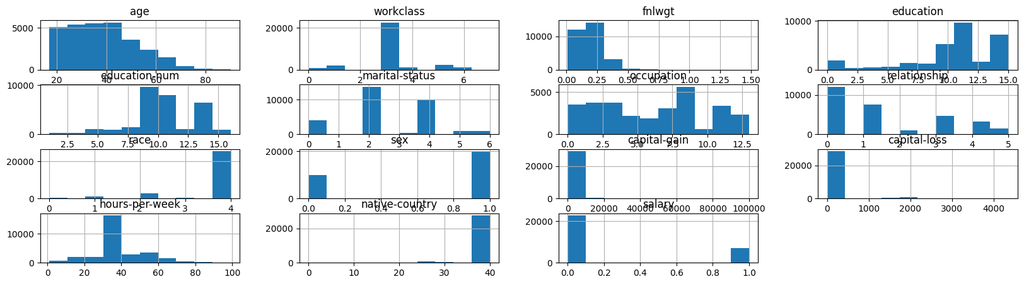

```python
enDF.hist()
```

##### These are the all columns histogram charts ; for example to analyze one of them you can see the average of ages are between 20 to 40 and out data is more focused on ages between 20 to 50

# Question 10 : Feature Engeenering

#### To normalize all columns of the dataframe, we first subtract the column mean, and then divide by the standard deviation.

```python
DF = (enDF - enDF.mean())/(enDF.std())
```

```python
DF.head(10)
```

|  | age | workclass | fnlwgt | education | education-num | marital-status | occupation | relationship | race | sex | capital-gain | capital-loss | hours-per-week | native-country | salary |
| --- | --- | --- | --- | --- | --- | --- | --- | --- | --- | --- | --- | --- | --- | --- | --- |
| 0 | 0.030660 | 2.622516 | -1.064998 | -0.336339 | 1.135745 | 0.918457 | -1.541412 | -0.278207 | 0.393610 | 0.703222 | 0.144193 | -0.215547 | -0.035288 | 0.261237 | -0.561735 |
| 1 | 0.836403 | 1.719563 | -1.010003 | -0.336339 | 1.135745 | -0.407149 | -0.787211 | -0.901237 | 0.393610 | 0.703222 | -0.146220 | -0.215547 | -2.228952 | 0.261237 | -0.561735 |
| 2 | -0.042589 | -0.086344 | 0.245859 | 0.181019 | -0.419659 | -1.732754 | -0.284409 | -0.278207 | 0.393610 | 0.703222 | -0.146220 | -0.215547 | -0.035288 | 0.261237 | -0.561735 |
| 3 | 1.056151 | -0.086344 | 0.426881 | -2.405769 | -1.197362 | -0.407149 | -0.284409 | -0.901237 | -1.962521 | 0.703222 | -0.146220 | -0.215547 | -0.035288 | 0.261237 | -0.561735 |
| 4 | -0.775082 | -0.086344 | 1.410883 | -0.336339 | 1.135745 | -0.407149 | 0.721193 | 2.213914 | -1.962521 | -1.421978 | -0.146220 | -0.215547 | -0.035288 | -5.351797 | -0.561735 |
| 5 | -0.115838 | -0.086344 | 0.900063 | 0.439697 | 1.524597 | -0.407149 | -0.787211 | 2.213914 | 0.393610 | -1.421978 | -0.146220 | -0.215547 | -0.035288 | 0.261237 | -0.561735 |
| 6 | 0.763153 | -0.086344 | -0.280448 | -1.112375 | -1.975064 | 0.255654 | 0.218392 | -0.278207 | -1.962521 | -1.421978 | -0.146220 | -0.215547 | -1.985212 | -2.380191 | -0.561735 |
| 7 | 0.982901 | 1.719563 | 0.188881 | 0.181019 | -0.419659 | -0.407149 | -0.787211 | -0.901237 | 0.393610 | 0.703222 | -0.146220 | -0.215547 | 0.370946 | 0.261237 | 1.780138 |
| 8 | -0.555334 | -0.086344 | -1.366164 | 0.439697 | 1.524597 | 0.918457 | 0.721193 | -0.278207 | 0.393610 | -1.421978 | 1.735182 | -0.215547 | 0.777180 | 0.261237 | 1.780138 |
| 9 | 0.250408 | -0.086344 | -0.287452 | -0.336339 | 1.135745 | -0.407149 | -0.787211 | -0.901237 | 0.393610 | 0.703222 | 0.545480 | -0.215547 | -0.035288 | 0.261237 | 1.780138 |

##### normalizing data is beneficial for machine learning models:

```
    1-  Avoids numerical instability:
          Normalizing data can help to avoid numerical instability that can occur when working with large or small values. By scaling the data to a smaller range, you can avoid numerical issues such as overflow or underflow.

    2- Improves convergence:
          Normalizing data can help these optimization methods converge more quickly and accurately, resulting in a better solution.

    3- Helps to compare features

    4- Improves model performance

    5- ***columns have different SCALE ***
```

##### normalizing data is good for NUMERICAL COLUMNS so :

```python
DF_nor = trainDF.copy()
for col in DF_nor :
    if (DF_nor[col].dtypes != object):
        print(col)
        DF_nor[col] = (DF_nor[col] - DF_nor[col].mean())/(DF_nor[col].std())
```

```
age
fnlwgt
education-num
capital-gain
capital-loss
hours-per-week
```

```python
DF_LE(DF_nor)
```

```python
DF_nor.describe()
```

|  | age | workclass | fnlwgt | education | education-num | marital-status | occupation | relationship | race | sex | capital-gain | capital-loss | hours-per-week | native-country | salary |
| --- | --- | --- | --- | --- | --- | --- | --- | --- | --- | --- | --- | --- | --- | --- | --- |
| count | 2.982500e+04 | 29825.000000 | 2.982500e+04 | 29825.000000 | 2.982500e+04 | 29825.000000 | 29825.000000 | 29825.000000 | 29825.000000 | 29825.000000 | 2.982500e+04 | 2.982500e+04 | 2.982500e+04 | 29825.000000 | 29825.000000 |
| mean | -1.639073e-16 | 2.871517 | 1.024420e-16 | 10.300218 | -1.243599e-16 | 2.614283 | 5.569355 | 1.446538 | 3.665884 | 0.669103 | -1.643837e-17 | -4.740922e-17 | 2.699229e-16 | 35.715407 | 0.239866 |
| std | 1.000000e+00 | 1.454510 | 1.000000e+00 | 3.865799 | 1.000000e+00 | 1.508745 | 4.231058 | 1.605059 | 0.848849 | 0.470544 | 1.000000e+00 | 1.000000e+00 | 1.000000e+00 | 7.833412 | 0.427009 |
| min | -1.580825e+00 | -1.000000 | -1.684042e+00 | 0.000000 | -3.530469e+00 | 0.000000 | -1.000000 | 0.000000 | 0.000000 | 0.000000 | -1.462195e-01 | -2.155473e-01 | -3.203914e+00 | -1.000000 | 0.000000 |
| 25% | -7.750821e-01 | 3.000000 | -6.822369e-01 | 9.000000 | -4.196595e-01 | 2.000000 | 2.000000 | 0.000000 | 4.000000 | 0.000000 | -1.462195e-01 | -2.155473e-01 | -3.528823e-02 | 38.000000 | 0.000000 |
| 50% | -1.158383e-01 | 3.000000 | -1.064960e-01 | 11.000000 | -3.080823e-02 | 2.000000 | 6.000000 | 1.000000 | 4.000000 | 1.000000 | -1.462195e-01 | -2.155473e-01 | -3.528823e-02 | 38.000000 | 0.000000 |
| 75% | 6.899042e-01 | 3.000000 | 4.473608e-01 | 12.000000 | 7.468942e-01 | 4.000000 | 9.000000 | 3.000000 | 4.000000 | 1.000000 | -1.462195e-01 | -2.155473e-01 | 3.709459e-01 | 38.000000 | 0.000000 |
| max | 3.766375e+00 | 7.000000 | 1.228926e+01 | 15.000000 | 2.302299e+00 | 6.000000 | 13.000000 | 5.000000 | 4.000000 | 1.000000 | 1.321208e+01 | 1.064201e+01 | 4.758274e+00 | 40.000000 | 1.000000 |

##### Another Approch for Nomalizing Data is : ( DF - min ) / ( max - min )

# Question 11 : Createing a Prediction Model

```python
DF_nor[(trainDF['salary'] == '<=50K')].count()
```

```
age               22671
workclass         22671
fnlwgt            22671
education         22671
education-num     22671
marital-status    22671
occupation        22671
relationship      22671
race              22671
sex               22671
capital-gain      22671
capital-loss      22671
hours-per-week    22671
native-country    22671
salary            22671
dtype: int64
```

```python
DF_nor[(trainDF['salary'] == '>50K')].count()
```

```
age               7154
workclass         7154
fnlwgt            7154
education         7154
education-num     7154
marital-status    7154
occupation        7154
relationship      7154
race              7154
sex               7154
capital-gain      7154
capital-loss      7154
hours-per-week    7154
native-country    7154
salary            7154
dtype: int64
```

```python
7154+22671 == DF_nor.count()
```

```
age               True
workclass         True
fnlwgt            True
education         True
education-num     True
marital-status    True
occupation        True
relationship      True
race              True
sex               True
capital-gain      True
capital-loss      True
hours-per-week    True
native-country    True
salary            True
dtype: bool
```

```python
moreThan50Mean = DF_nor[(trainDF['salary'] == '<=50K')].mean()
```

```python
moreThan50Std = DF_nor[(trainDF['salary'] == '<=50K')].std()
```

```python
lessThan50Mean = DF_nor[(trainDF['salary'] == '>50K')].mean()
```

```python
lessThan50Std = DF_nor[(trainDF['salary'] == '>50K')].std()
```

```python
import scipy.stats as stats
```

```python
def drawGraphs (moreThan50Mean , moreThan50Std , lessThan50Mean , lessThan50Std , DF_nor):
    colNum = 0
    for col in DF_nor:
        moreThan50DistValues = stats.norm(moreThan50Mean[colNum] , moreThan50Std[colNum])
        lessThan50DistValues = stats.norm(lessThan50Mean[colNum] , lessThan50Std[colNum])
        xValue = DF_nor[col].unique()
        xValue.sort()

        plt.plot(xValue, moreThan50DistValues.pdf(xValue), label='More than 50')
        plt.plot(xValue, lessThan50DistValues.pdf(xValue), label='Less than 50')
        plt.legend()
        plt.xlabel(col)
        plt.tick_params(which="minor" , direction = 'in' , length = 4 , width = 1 , labelsize = 10)


        plt.grid(which='major' , axis='both' , linestyle = '--' , color="black")
        plt.grid(which='minor' , axis='both' , linestyle = ':' , color="gray")
        plt.minorticks_on()

        plt.ylabel(f"PDF of {col}")
        plt.title(f"PDF of {col} per {col}")
        plt.tight_layout()
        plt.show()
        colNum +=1
        if (col == 'native-country'):
            break
```

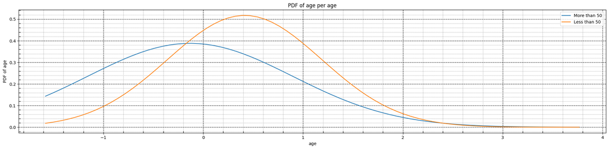

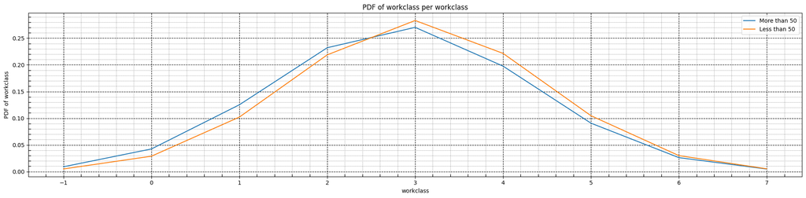

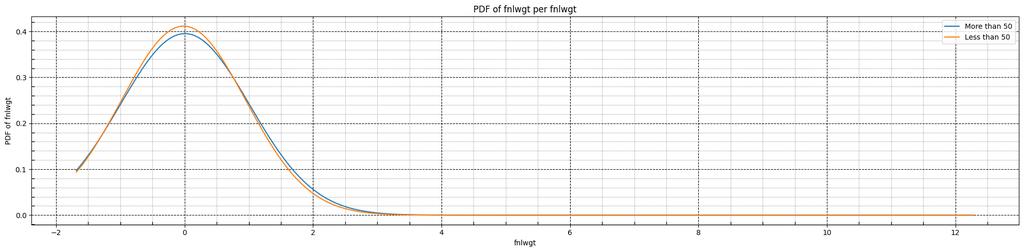

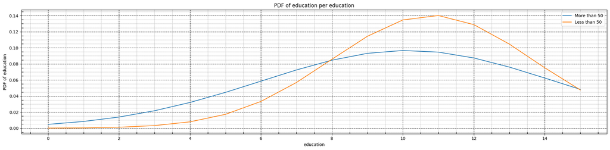

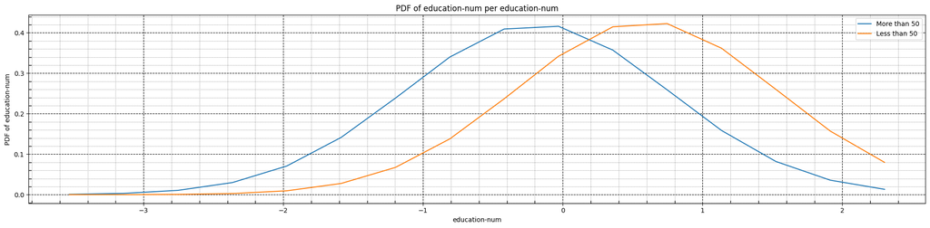

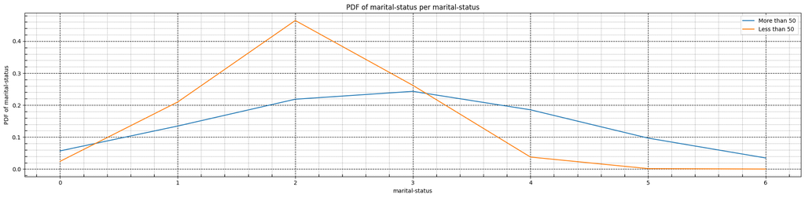

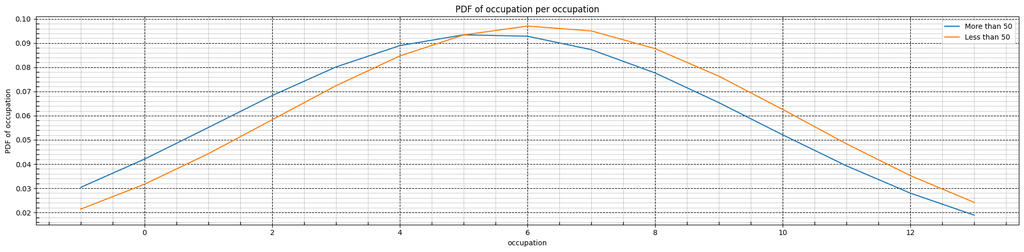

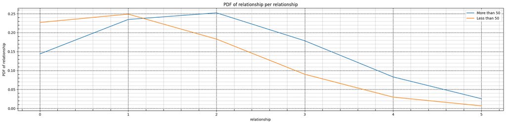

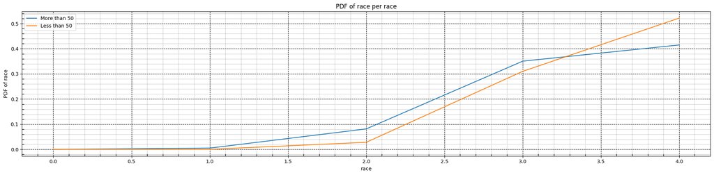

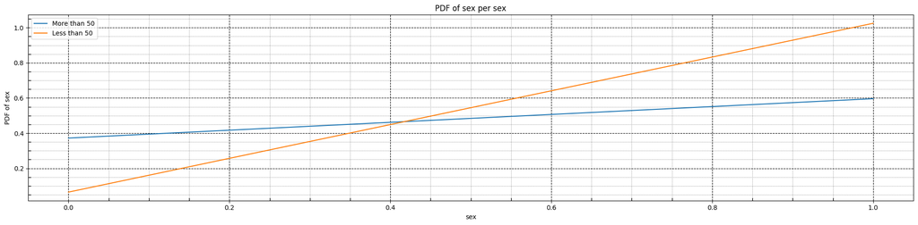

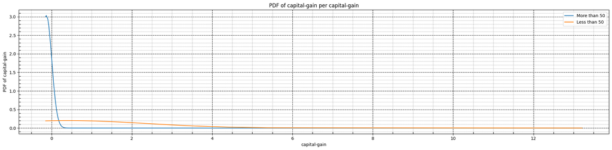

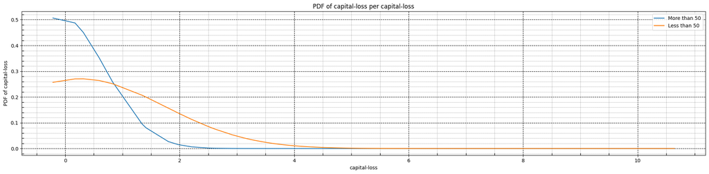

[2 more figures not shown]

```python
drawGraphs(moreThan50Mean , moreThan50Std , lessThan50Mean , lessThan50Std , DF_nor)
```

```python
listOfPred = []
```

```python
def predictionOn (prop , DF_nor , intersectionValue , fromLeftBlueIsUp , trainDF , listOfPred):
    truePred = 0
    DF_nor[f'pred_on_{prop}'] = np.nan
    if (fromLeftBlueIsUp == 1):
        DF_nor.loc[(DF_nor[prop] >= intersectionValue) , f'pred_on_{prop}' ] = ">50K"
        DF_nor.loc[(DF_nor[prop] < intersectionValue), f'pred_on_{prop}' ] = "<=50K"
    else :
        DF_nor.loc[(DF_nor[prop] >= intersectionValue) , f'pred_on_{prop}' ]  = "<=50K"
        DF_nor.loc[(DF_nor[prop] < intersectionValue) , f'pred_on_{prop}' ]  = ">50K"

    truePred = (DF_nor[ f'pred_on_{prop}'] ==  trainDF['salary']).sum()

    #print (f"{prop} : " ,truePred / len(DF_nor.index) * 100)
    listOfPred.append([f"{prop} : " ,truePred / len(DF_nor.index) * 100])
```

```python
predictionOn('age',DF_nor ,1.5 ,1 , trainDF , listOfPred)

predictionOn('workclass',DF_nor ,3 ,1 , trainDF , listOfPred)

predictionOn('fnlwgt',DF_nor ,0 ,0 , trainDF , listOfPred)

predictionOn('education',DF_nor ,10.5 ,1 , trainDF , listOfPred)

predictionOn('education-num',DF_nor ,0.2 ,1 , trainDF , listOfPred)

predictionOn('marital-status',DF_nor ,2.41 ,0 , trainDF , listOfPred)

predictionOn('occupation',DF_nor ,5.75 ,1 , trainDF , listOfPred)

predictionOn('relationship',DF_nor ,1.2 , 0 , trainDF , listOfPred)

predictionOn('race',DF_nor ,3.7 ,1 , trainDF, listOfPred)

predictionOn('capital-loss',DF_nor ,0.25 ,1 , trainDF, listOfPred)

predictionOn('hours-per-week',DF_nor ,0.15 ,1 , trainDF, listOfPred)

predictionOn('native-country',DF_nor ,36 ,1 , trainDF, listOfPred)

predictionOn('capital-gain',DF_nor ,1.25 ,1 , trainDF, listOfPred)
```

```python
def secondVal (arr):
        return arr[1]


listOfPred.sort(key=secondVal , reverse=1)
def printPred (l):
    for i in l:
        print (i[0] , i[1])
```

# Best Preditions :

```python
printPred(listOfPred)
```

```
capital-gain :  78.31349538977368
capital-loss :  76.03688181056161
age :  71.89270746018441
education-num :  71.51047778709136
hours-per-week :  70.487845766974
marital-status :  60.20117351215424
relationship :  51.460184409052815
occupation :  50.38055322715842
fnlwgt :  47.63118189438391
education :  41.223805532271584
race :  34.179379715004195
workclass :  31.875943000838227
native-country :  30.055322715842415
```

```
if you have a normal distribution plot and you want to understand which property is the best to predict from that plot, you can look at the mean and variance of the distribution.


 - The mean of the normal distribution represents the center of the distribution. If the mean of a property is significantly different from the mean of the distribution, it may be a good predictor of the outcome you are interested in.


 - The variance of the normal distribution represents the spread of the distribution. If the variance of a property is significantly larger or smaller than the variance of the distribution, it may also be a good predictor of the outcome you are interested in.


- and some other parameters like :
        skewness, kurtosis, and any statistical tests that may be appropriate for your data.
```

# Question 12:

##### This DataSet was given by TA and it was about some informations on people and then catogorized them based on their SALARY (THIS WAS TEST DF)

```python
testDF = pd.read_csv("/Users/Mahdi/Downloads/test.csv")
```

```python
testDF.head()
```

|  | age | workclass | fnlwgt | education | education-num | marital-status | occupation | relationship | race | sex | capital-gain | capital-loss | hours-per-week | native-country | salary |
| --- | --- | --- | --- | --- | --- | --- | --- | --- | --- | --- | --- | --- | --- | --- | --- |
| 0 | 25 | Private | 230292 | HS-grad | 9 | Married-civ-spouse | Craft-repair | Husband | White | Male | 0 | 0 | 40 | United-States | <=50K |
| 1 | 36 | Private | 90159 | Bachelors | 13 | Married-civ-spouse | Prof-specialty | Wife | White | Female | 0 | 0 | 32 | United-States | >50K |
| 2 | 40 | Private | 175398 | Assoc-voc | 11 | Divorced | Prof-specialty | Not-in-family | White | Female | 0 | 0 | 20 | United-States | <=50K |
| 3 | 56 | Self-emp-not-inc | 53366 | 11th | 7 | Married-civ-spouse | Craft-repair | Husband | White | Male | 0 | 0 | 20 | United-States | <=50K |
| 4 | 50 | Private | 46155 | Assoc-voc | 11 | Divorced | Prof-specialty | Unmarried | White | Female | 0 | 0 | 40 | United-States | >50K |

```python
testDF_nor = testDF.copy()
for col in testDF_nor  :
    if (testDF_nor[col].dtypes != object):
        print(col)
        testDF_nor [col] = (testDF_nor [col] - testDF_nor [col].mean())/(testDF_nor [col].std())
DF_LE(testDF_nor)
```

```
age
fnlwgt
education-num
capital-gain
capital-loss
hours-per-week
```

```python
testDF_nor.head()
```

|  | age | workclass | fnlwgt | education | education-num | marital-status | occupation | relationship | race | sex | capital-gain | capital-loss | hours-per-week | native-country | salary |
| --- | --- | --- | --- | --- | --- | --- | --- | --- | --- | --- | --- | --- | --- | --- | --- |
| 0 | -1.005027 | 3 | 0.372971 | 11 | -0.42426 | 2 | 2 | 0 | 4 | 1 | -0.14447 | -0.228418 | -0.036922 | 36 | 0 |
| 1 | -0.191184 | 3 | -0.930951 | 9 | 1.12344 | 2 | 9 | 5 | 4 | 0 | -0.14447 | -0.228418 | -0.663401 | 36 | 1 |
| 2 | 0.104759 | 3 | -0.137812 | 8 | 0.34959 | 0 | 9 | 1 | 4 | 0 | -0.14447 | -0.228418 | -1.603119 | 36 | 0 |
| 3 | 1.288531 | 5 | -1.273306 | 1 | -1.19811 | 2 | 2 | 0 | 4 | 1 | -0.14447 | -0.228418 | -1.603119 | 36 | 0 |
| 4 | 0.844616 | 3 | -1.340403 | 8 | 0.34959 | 0 | 9 | 4 | 4 | 0 | -0.14447 | -0.228418 | -0.036922 | 36 | 1 |

```python
def drawGraphOfCG (moreThan50Mean , moreThan50Std , lessThan50Mean , lessThan50Std , DF_nor):

    moreThan50DistValues = stats.norm(moreThan50Mean , moreThan50Std)
    lessThan50DistValues = stats.norm(lessThan50Mean , lessThan50Std)
    xValue = DF_nor['capital-gain'].unique()
    xValue.sort()

    plt.plot(xValue, moreThan50DistValues.pdf(xValue), label='More than 50')
    plt.plot(xValue, lessThan50DistValues.pdf(xValue), label='Less than 50')
    plt.legend()
    plt.xlabel("capital Loss")
    plt.tick_params(which="minor" , direction = 'in' , length = 4 , width = 1 , labelsize = 10)


    plt.grid(which='major' , axis='both' , linestyle = '--' , color="black")
    plt.grid(which='minor' , axis='both' , linestyle = ':' , color="gray")
    plt.minorticks_on()

    plt.ylabel(f"PDF of capital Loss")
    plt.title(f"PDF of capital Loss per capital Loss")
    plt.tight_layout()
    plt.show()
```

```python
lessThan50Std_test = testDF_nor[(testDF['salary'] == '>50K')]['capital-gain'].std()
```

```python
lessThan50Mean_test = testDF_nor[(testDF['salary'] == '>50K')]['capital-gain'].mean()
```

```python
moreThan50Std_test = testDF_nor[(testDF['salary'] == '<=50K')]['capital-gain'].std()
```

```python
moreThan50Mean_test = testDF_nor[(testDF['salary'] == '<=50K')]['capital-gain'].mean()
```

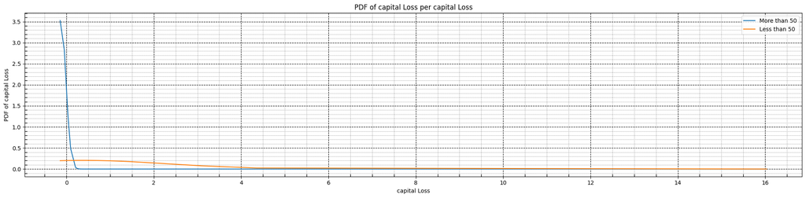

```python
drawGraphOfCG (moreThan50Mean_test , moreThan50Std_test , lessThan50Mean_test , lessThan50Std_test ,testDF_nor)
```

```python
listOftestPred = []
predictionOn('capital-gain' ,testDF_nor ,0.3,1,testDF,listOftestPred)
```

```python
printPred(listOftestPred)
```

```
capital-gain :  78.32602339181285
```

```python
testDF_nor.head()
```

|  | age | workclass | fnlwgt | education | education-num | marital-status | occupation | relationship | race | sex | capital-gain | capital-loss | hours-per-week | native-country | salary | pred_on_capital-gain |
| --- | --- | --- | --- | --- | --- | --- | --- | --- | --- | --- | --- | --- | --- | --- | --- | --- |
| 0 | -1.005027 | 3 | 0.372971 | 11 | -0.42426 | 2 | 2 | 0 | 4 | 1 | -0.14447 | -0.228418 | -0.036922 | 36 | 0 | <=50K |
| 1 | -0.191184 | 3 | -0.930951 | 9 | 1.12344 | 2 | 9 | 5 | 4 | 0 | -0.14447 | -0.228418 | -0.663401 | 36 | 1 | <=50K |
| 2 | 0.104759 | 3 | -0.137812 | 8 | 0.34959 | 0 | 9 | 1 | 4 | 0 | -0.14447 | -0.228418 | -1.603119 | 36 | 0 | <=50K |
| 3 | 1.288531 | 5 | -1.273306 | 1 | -1.19811 | 2 | 2 | 0 | 4 | 1 | -0.14447 | -0.228418 | -1.603119 | 36 | 0 | <=50K |
| 4 | 0.844616 | 3 | -1.340403 | 8 | 0.34959 | 0 | 9 | 4 | 4 | 0 | -0.14447 | -0.228418 | -0.036922 | 36 | 1 | <=50K |

```python
testDF_nor.to_csv('/Users/Mahdi/Desktop/TEST_DF.csv')
```

## Conclusion:

#### By checkcing all relational parameters we can create a model to predict based on best proprty in DF

#### To make it better and predict much more accurate , we can predict based on multipy parameters

## Refrences:

```
 - geekforgeeks
 - AI of RUSSEL
 - matplotlib docs
 - pandas docs
 - towardTODataSciece
```